# Атлас рутульских диалектов

## Атлас диалектов рутульского языка

На сайте представлены результаты диалектологического обследования двенадцати рутульских сёл, расположенных в Рутульском и Ахтынском районах Республики Дагестан (Россия). Это сёла Амсар, Джилихур, Ихрек, Кала, Кина, Киче, Куфа, Лучек, Мюхрек, Рутул, Хнов, Шиназ.

[Рутульский язык](https://ru.wikipedia.org/wiki/%D0%A0%D1%83%D1%82%D1%83%D0%BB%D1%8C%D1%81%D0%BA%D0%B8%D0%B9_%D1%8F%D0%B7%D1%8B%D0%BA) принадлежит к лезгинской ветви нахско-дагестанской языковой семьи. Большинство носителей этого языка (около 33 тысяч человек, [согласно переписи 2020 года](https://rosstat.gov.ru/vpn_popul)) проживают в Дагестане.

Рутульские диалекты были обследованы в июле 2022 года в рамках лингвистической экспедиции [Школы лингвистики НИУ ВШЭ](https://ling.hse.ru/) (Москва). Опрос носителей рутульских диалектов проводился по единой анкете, составленной участниками исследовательской группы. При составлении анкеты были учтены имеющиеся описания рутульских диалектов (Ибрагимов 2004, 1978; Alekseyev 2016, 1994; Алисултанов, Сулейманова 2019; Исмаилова 2011; Исламов 2014; Алисултанов, Исламов 2022; Махмудова 2002; Ибрагимова 2009; Authier б. д.-b, б. д.-a, 2023; Дирр 1912; Джамалов 2006). При этом мы стремились не только задокументировать и количественно оценить уже известные параметры диалектного варьирования, но и по возможности выявить новые, ранее не изученные региональные варианты.

Для каждого исследуемого явления было составлено несколько предложений-стимулов на русском языке. В каждой обследованной деревне были записаны переводы этих предложений двумя, тремя или четырьмя носителями. Исследовались диалектные различия в области лексики, фонетики, морфологии и синтаксиса.

Нашей основной целью являлось систематическое картирование диалектной вариативности. Вариативность в реализации того или иного явления (отражается на картах разным цветом) отмечается не только между деревнями, но и между жителями одной деревни, а иногда и в речи одного говорящего. Такие случаи отражены на карте в виде кружков, содержащих доли разного цвета. Относительная частотность вариантов на картах не отражается.

Диалектные различия, представленные в Атласе, основаны исключительно на нашем исследовании. Поэтому возможна ситуация, когда некоторая диалектная черта не отражена на карте Атласа для определенной деревни, притом что она отмечена в литературе. Иными словами, Атлас отражает диалектное разнообразие рутульского языка лишь частично.

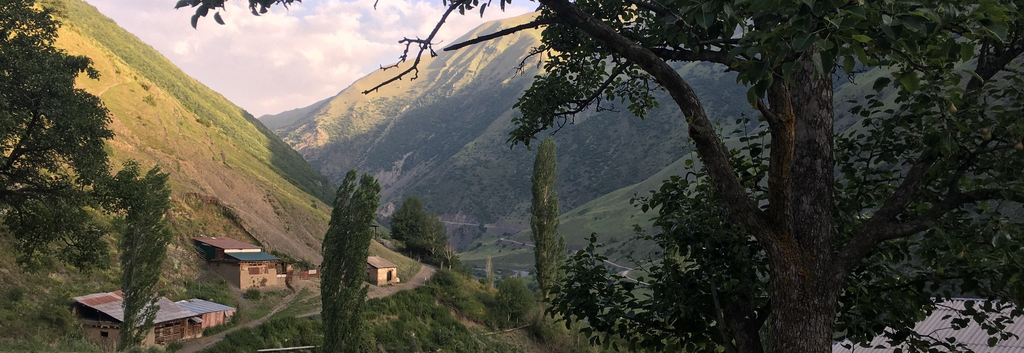

### Благодарность

Авторы проекта выражают глубокую благодарность жителям рутульских сёл за их гостеприимство и готовность переводить, объяснять и помогать.

### Как ссылаться на данные проекта

Anastasia Alekseeva, Nikita Beklemishev, Michael Daniel, Nina Dobrushina, Konstantin Filatov, Anastasia Ivanova, Timur Maisak, Maxim Melenchenko, George Moroz, Ivan Netkachev, Ilya Sadakov. Atlas of Rutul dialects. Moscow: Linguistic Convergence Laboratory, HSE University. https://lingconlab.github.io/rutul_dialectology/index.html

### Финансовая поддержка

Проект поддерживается Международной лабораторией языковой конвергенции. Корпус создан в рамках Программы фундаментальных исследований [НИУ ВШЭ](https://www.hse.ru/).

## использованная литература

Alekseyev, M. (1994). Rutul. В R. Smeets (Ред.), *The North East Caucasian Languages* (сс. 213–258). Delmar, NY: Caravan Press.

Alekseyev, M. (2016). Rutul. В P. O. Müller, I. Ohnheiser, S. Olsen, F. Rainer (Ред.), *An International Handbook of the Languages of Europe* (сс. 3536–3545). Berlin, Boston: De Gruyter Mouton.

Authier, G. (б. д.-a). *Ikhrek Rutul*.

Authier, G. (б. д.-b). *Mukhad Rutul*.

Authier, G. (2023). The Khnov dialect of Southern Rutul. В J. Garibova, E. Ragagnin (Ред.), *Linguistic diversity in Azerbaijan: Present state and future challenges* (сс. 299–372). Ankara: Grafiker Yayınları.

Алисултанов, А. С., Исламов, Р. А. (2022). *Хновский (Хинанаад) говор рутульского языка*. Махачкала: Алеф.

Алисултанов, А. С., Сулейманова, Т. А. (2019). *Русско-рутульский словарь*. Махачкала: Алеф.

Джамалов, К. Э. (2006). *Рутульско-русский словарь (ихрекский диаелкт)*. Москва: Экон-Информ.

Дирр, А. М. (1912). *Рутульский язык*. Тифлис: Издание управления кавказского учебного округа.

Ибрагимов, Г. Х. (1978). *Рутульский язык*. Москва: Академия Наук СССР.

Ибрагимов, Г. Х. (2004). *Рутульский язык*. Махачкала: Народы Дагестана.

Ибрагимова, Л. М. (2009). *Мюхрекский диалект рутульского языка* (Phdthesis). ДГПУ, Махачкала.

Исламов, Р. А. (2014). *Хновский говор борчинско-хновского диалекта рутульского языка: фонетика, морфология, лексика* (Phdthesis). ДГПУ, Махачкала.

Исмаилова, Э. И. (2011). *Русско-рутульский словарь*. Махачкала: ДНЦ РАН Институт языка, литературы и искусства им. Г. Цадасы и Институт эволюционной антропологии им. М. Планка.

Махмудова, С. (2002). *Грамматические классы слов и граматические категории рутульского языка*. Москва: Советский писатель.